# Assignment 3 Task 3

Matt Koller

11/2/2020

## Introduction

In this document, I will read in, wrangle, and explore data about urchins observed in five locations near Santa Barbara from 2008 through 2020. I will assess whether the data is normally distributed, and create a graph of the data.

## I. SECTION 1

## 1. Read in data

Here I will read in, clean, and wrangle the urchins data.

```r
urchins <- read_csv(here("data", "urchins.csv")) %>% #Read in the urchins data from the data subfolder
  clean_names() #clean the column names to read in lower snake case
```

Here I will wrangle my data to show just the urchin name and size, so I can begin to play around with it.

```r
urchin_size <- urchins %>% #create a new dataset named urchin_size, comprised of...
  select(size,  common_name) #the size and common_name columns
```

## 2. Exploring data visually

I will now create a histogram for both Purple Urchins and Red Urchins, and explore whether the data appears to be normally distributed for both.

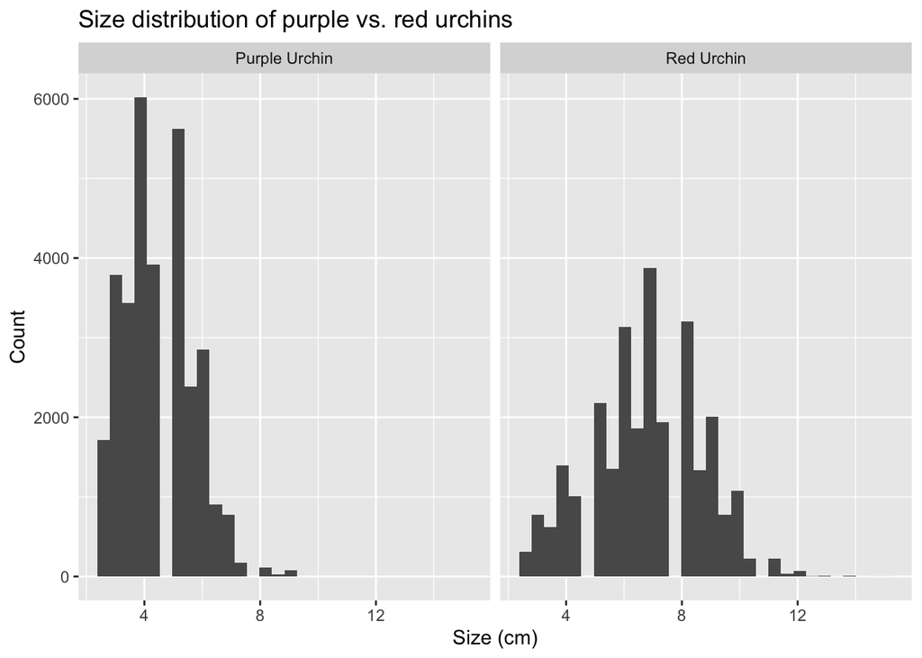

```r
ggplot(data = urchin_size, aes(x = size)) + #create a ggplot based on the urchin_size data; the size will go along the x-axis
  geom_histogram() + #the ggplot will be a histogram, with bins equalling 20
  facet_wrap(~common_name) + #this will create two different histograms, one for each kind of urchin
  labs(x = "Size (cm)", #label the x-axis
       y = "Count", #label the y-axis
       title = "Size distribution of purple vs. red urchins") #label the graph
```

I will now create a boxplot for both Purple Urchins and Red Urchins.

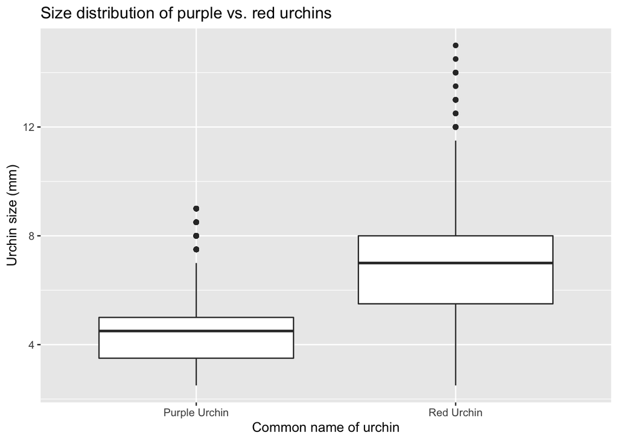

```r
ggplot(data = urchin_size, aes(common_name, size))+ #crete a ggplot comparing common_name and size
  geom_boxplot() + #make this ggplot a boxplot
  labs(x = "Common name of urchin", #label the x-axis
       y = "Urchin size (mm)", #label the y-axis
       title = "Size distribution of purple vs. red urchins") #label the graph
```